# SyntheticData_simulation

Mirthe Hendriks

10-6-2021

# Aim

The aim of this simulation study is to establish a proof-of-concept for generating high-quality synthetic data with multiple imputations in MICE for the analysis of privacy-sensitive data. We conduct a Monte Carlo simulation to generate repeated samples of synthetic data. The observed data comes from the Pima Indians Diabetes (PID) dataset with actual observed values. The study answers the following research questions: 1. Do the observed data and the synthetic data yield the same univariate statistical properties? 2. Do the observed data and the synthetic data yield the same statistical inferences, i.e. are the estimates unbiased and confidence valid? 3. Can we discriminate between the observed data and the synthetic data with a prediction model?

## Fix random seed

In this simulation, we will be using random numbers. We set the seed of the random number generator in order to be able to reproduce the results in this document.

```r
set.seed(123) #seed for reproducibility
```

## Loading required packages

```r
library(mice)     # data imputation
library(magrittr) # piping
library(dplyr)    # data manipulation
library(purrr)    # functional programming
library(furrr)    # parallel mapping
library(tidyr)    # tidy data
library(tidyverse)# tidy packages
library(tibble)   # data formats
library(caret)    # classification and regression trees
library(mboost)   # for prediction model with method glmboost for classification
library(broom)    # tidy tibbles
library(corrplot) # correlation plot
library(ggplot2)  # plots
library(DT)       # tables
library(psych)
```

## Number of simulations

Let us define the number of replications (i.e. simulations) for this Monte Carlo experiment.

```r
nsim = 1000
```

# True data

```r
truedata <- read_csv("diabetes.csv",
                 col_types = cols(Pregnancies = col_integer(),
                                  Glucose = col_integer(),
                                  BloodPressure = col_integer(),
                                  SkinThickness = col_integer(),
                                  Insulin = col_integer(),
                                  Age = col_integer(),
                                  Outcome = col_factor(levels = c("0", "1"))))
```

## Impute missing values in data

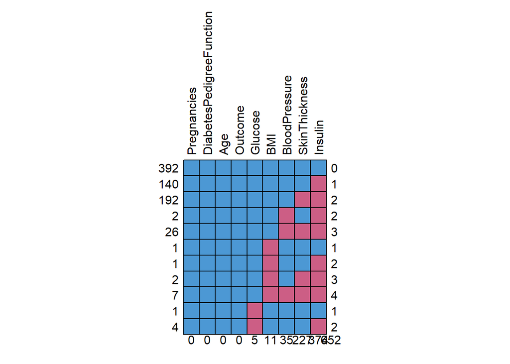

```
##     Pregnancies DiabetesPedigreeFunction Age Outcome Glucose BMI BloodPressure
## 392           1                        1   1       1       1   1             1
## 140           1                        1   1       1       1   1             1
## 192           1                        1   1       1       1   1             1
## 2             1                        1   1       1       1   1             0
## 26            1                        1   1       1       1   1             0
## 1             1                        1   1       1       1   0             1
## 1             1                        1   1       1       1   0             1
## 2             1                        1   1       1       1   0             1
## 7             1                        1   1       1       1   0             0
## 1             1                        1   1       1       0   1             1
## 4             1                        1   1       1       0   1             1
##               0                        0   0       0       5  11            35
##     SkinThickness Insulin
## 392             1       1   0
## 140             1       0   1
## 192             0       0   2
## 2               1       0   2
## 26              0       0   3
## 1               1       1   1
## 1               1       0   2
## 2               0       0   3
## 7               0       0   4
## 1               1       1   1
## 4               1       0   2
##               227     374 652
```

```r
#set the zeros to NA in the selected columns
truedata[2:6][truedata[2:6] == 0] <- NA
md.pattern(truedata, rotate.names = TRUE)
```

```r
#impute the missing data once
truedata <- truedata %>%
  mice(seed=123, m=1, print = FALSE) %>% # impute once
  mice::complete() # extract completed data
```

```r
describe(truedata) %>% select(c('mean', 'sd', 'median', 'skew', 'kurtosis','se')) %>%
  datatable() %>% formatRound(columns=c('mean', 'sd', 'skew', 'kurtosis','se'), digits=4)
```

|  | mean | sd | median | skew | kurtosis | se |
| --- | --- | --- | --- | --- | --- | --- |
| Pregnancies | 3.84505208333333 | 3.36957806269887 | 3 | 0.898154872604808 | 0.142183957122032 | 0.121589175097166 |
| Glucose | 121.72265625 | 30.5829055919728 | 117 | 0.52988333399415 | -0.301060932736552 | 1.1035655485079 |
| BloodPressure | 72.2421875 | 12.301352631501 | 72 | 0.136632813815634 | 0.891939834767939 | 0.443886828324602 |
| SkinThickness | 29.171875 | 10.6700736933069 | 29 | 0.824999158920444 | 3.77171650347063 | 0.385023119943992 |
| Insulin | 146.670572916667 | 109.816853904565 | 117.5 | 2.04898334916887 | 5.75848937151925 | 3.96267438520991 |
| BMI | 32.4236979166667 | 6.8924981135291 | 32.3 | 0.60157420329542 | 0.87253955631307 | 0.248711602577188 |
| DiabetesPedigreeFunction | 0.471876302083333 | 0.331328595012775 | 0.3725 | 1.91241792381955 | 5.52853885711983 | 0.0119557908450529 |
| Age | 33.2408854166667 | 11.7602315406787 | 29 | 1.12518804431459 | 0.621726907802015 | 0.424360802858948 |
| Outcome* | 1.34895833333333 | 0.476951377242799 | 1 | 0.632538262922643 | -1.60197616835257 | 0.0172105003775933 |

# Analysis model

We define the following model for analysis in this simulation
$$Outcome= β_0+β_1 BMI+β_2 Glucose+β_3 Pregnancies$$

```r
model <- truedata %$%
  glm(Outcome~BMI+Glucose+Pregnancies,family=binomial(link = "logit"))
summary(model)
```

```
##
## Call:
## glm(formula = Outcome ~ BMI + Glucose + Pregnancies, family = binomial(link = "logit"))
##
## Deviance Residuals:
##     Min       1Q   Median       3Q      Max
## -2.2681  -0.7059  -0.4104   0.7176   2.3649
##
## Coefficients:
##              Estimate Std. Error z value Pr(>|z|)
## (Intercept) -8.864105   0.682160 -12.994  < 2e-16 ***
## BMI          0.090332   0.014596   6.189 6.06e-10 ***
## Glucose      0.037419   0.003453  10.838  < 2e-16 ***
## Pregnancies  0.137254   0.027226   5.041 4.62e-07 ***
## ---
## Signif. codes:  0 '***' 0.001 '**' 0.01 '*' 0.05 '.' 0.1 ' ' 1
##
## (Dispersion parameter for binomial family taken to be 1)
##
##     Null deviance: 993.48  on 767  degrees of freedom
## Residual deviance: 723.11  on 764  degrees of freedom
## AIC: 731.11
##
## Number of Fisher Scoring iterations: 5
```

# Generate synthetic data

```r
plan(multisession)

#specify pmm method
meth <- make.method(truedata)
meth <- rep('pmm',ncol(truedata))
names(meth) <- colnames(truedata)
meth['Outcome'] <- 'logreg'

#specify predictor matrix
pred <- make.predictorMatrix(truedata)

syn_pmm <- future_map(1:nsim, function(x){
                    mice(truedata,
                            m=5,
                            method = meth,
                            predictorMatrix = pred,
                            where=matrix(TRUE, nrow(truedata), ncol(truedata)),
                            print=FALSE)},
                    .options=future_options(seed=as.integer(123)), .progress=TRUE)
syn_cart_m <- future_map(1:nsim, function(x){
                  mice(truedata,
                          m=5,
                          meth = "cart",
                          where = matrix(TRUE, nrow(truedata), ncol(truedata)),
                          cp = 0.0001,
                          minbucket = 3,
                          print = FALSE)},
                  .options = furrr_options(seed = as.integer(123)), .progress = T)

syn_cart_cpm <- future_map(1:nsim, function(x){
                  mice(truedata,
                          m=5,
                          meth = "cart",
                          where = matrix(TRUE, nrow(truedata), ncol(truedata)),
                          cp = 1e-32,
                          minbucket = 3,
                          print = FALSE)},
                  .options = furrr_options(seed = as.integer(123)), .progress = T)
```

# Evaluate the synthetic data

```r
source("SyntheticData_functions.R")

column_names= c('True Est', 'Syn Est', 'Bias', 'CIW')

syn_pmm %>%
  map(~.x %$%
        glm(Outcome~BMI+Glucose+Pregnancies,family=binomial(link = "logit"))) %>%
  map_dfr(pool3.syn) %>%
  ci_cov(., model) %>%
  datatable() %>% formatRound(columns=column_names,digits=4) %>% formatRound(columns='Coverage',digits=2)
```

|  | term | True Est | Syn Est | Bias | CIW | Coverage |
| --- | --- | --- | --- | --- | --- | --- |
| 1 | (Intercept) | -8.8641054900233 | -4.48860465469483 | 4.37550083532847 | 2.27123769821946 | 0 |
| 2 | BMI | 0.0903320364106011 | 0.0476710788107844 | -0.0426609575998167 | 0.0575457318668846 | 0.042 |
| 3 | Glucose | 0.0374187000033661 | 0.0164508946961539 | -0.0209678053072122 | 0.0130657370313195 | 0 |
| 4 | Pregnancies | 0.137253923450965 | 0.0696245832406817 | -0.0676293402102836 | 0.110806379936551 | 0.174 |

```r
syn_cart_m %>%
  map(~.x %$%
        glm(Outcome~BMI+Glucose+Pregnancies,family=binomial(link = "logit"))) %>%
  map_dfr(pool3.syn) %>%
  ci_cov(., model) %>%
  datatable() %>% formatRound(columns=column_names,digits=4) %>% formatRound(columns='Coverage',digits=2)
```

|  | term | True Est | Syn Est | Bias | CIW | Coverage |
| --- | --- | --- | --- | --- | --- | --- |
| 1 | (Intercept) | -8.8641054900233 | -8.30175915060479 | 0.562346339418507 | 2.82015963748922 | 0.999 |
| 2 | BMI | 0.0903320364106011 | 0.0916206215045273 | 0.0012885850939262 | 0.0603719286317104 | 1 |
| 3 | Glucose | 0.0374187000033661 | 0.0331173742736397 | -0.00430132572972639 | 0.0142527062109791 | 0.985 |
| 4 | Pregnancies | 0.137253923450965 | 0.122684132449552 | -0.0145697910014137 | 0.112394466979629 | 1 |

```r
syn_cart_cpm %>%
  map(~.x %$%
        glm(Outcome~BMI+Glucose+Pregnancies,family=binomial(link = "logit"))) %>%
  map_dfr(pool3.syn) %>%
  ci_cov(., model) %>%
  datatable() %>% formatRound(columns=column_names,digits=4) %>% formatRound(columns='Coverage',digits=2)
```

|  | term | True Est | Syn Est | Bias | CIW | Coverage |
| --- | --- | --- | --- | --- | --- | --- |
| 1 | (Intercept) | -8.8641054900233 | -8.31199771511386 | 0.552107774909439 | 2.82088313566768 | 1 |
| 2 | BMI | 0.0903320364106011 | 0.0916890939347599 | 0.00135705752415886 | 0.0604757876360105 | 1 |
| 3 | Glucose | 0.0374187000033661 | 0.0331796224268696 | -0.00423907757649649 | 0.0142183041448118 | 0.984 |
| 4 | Pregnancies | 0.137253923450965 | 0.122818765849101 | -0.0144351576018642 | 0.112291027943904 | 1 |

# Univariate statistical properties

```r
uni <- syn_cart_m %>%
  map(~.x %>%
        complete("all") %>%
        map(~.x %>%
            describe()) %>% Reduce("+", .) / 5) %>%
  Reduce("+", .) / 1000
true <- describe(truedata)
(uni - true) %>% select(c("mean", "sd", "median", "skew", "kurtosis", "se")) %>%
  datatable()
```

|  | mean | sd | median | skew | kurtosis | se |
| --- | --- | --- | --- | --- | --- | --- |
| Pregnancies | 0.000117447916662794 | -1.8494383278167e-05 | 0 | -0.00189146527941586 | -0.0092281045044379 | -6.67358572875587e-07 |
| Glucose | 0.00187057291674364 | -0.00263640807144938 | 0.0873999999999313 | -0.00215462735672844 | -0.00325857065831697 | -9.51331818570544e-05 |
| BloodPressure | -0.00629270833329088 | -0.0021340797039997 | 0.0139999999999816 | -0.00211458255273525 | -0.0247739308046825 | -7.70069682231034e-05 |
| SkinThickness | 0.00419270833331709 | -0.00439840909674949 | 0.247800000000147 | -0.0318796745840083 | -0.271945607204618 | -0.000158713917251085 |
| Insulin | 0.0130356770831099 | -0.0759911756254752 | -0.036500000000018 | -0.0181255039694017 | -0.147114308034011 | -0.00274209535646586 |
| BMI | -0.00176166666663846 | -0.00515247243809736 | -0.0816799999999631 | -0.00796953588111149 | -0.0452167079926749 | -0.000185923834320867 |
| DiabetesPedigreeFunction | 7.86062500002238e-05 | -0.000177369632408053 | 0.000421200000000232 | -0.0210747944357397 | -0.158931620533032 | -6.40027531355683e-06 |
| Age | -0.000291927083360122 | -0.00274872483835154 | 0.0468000000000508 | -0.00163965463465732 | -0.00592128579468487 | -9.91860640842113e-05 |
| Outcome* | -0.000143749999997445 | -0.000139363071587018 | 0 | 0.0010363652642118 | 0.00304250381406068 | -5.02883168103374e-06 |

```r
uni_cp <- syn_cart_cpm %>% #or syn_cart_m
  map(~.x %>%
        complete("all") %>%
        map(~.x %>%
            describe()) %>% Reduce("+", .) / 5) %>%
  Reduce("+", .) / 1000
true <- describe(truedata)
(uni_cp - true) %>% select(c("mean", "sd", "median", "skew", "kurtosis", "se")) %>%
  datatable()
```

|  | mean | sd | median | skew | kurtosis | se |
| --- | --- | --- | --- | --- | --- | --- |
| Pregnancies | -0.000522135416662017 | -0.0019657552822383 | 0 | -0.00244974202600601 | -0.00877164229419775 | -7.09330838351008e-05 |
| Glucose | -0.00182630208348655 | -0.0166244071654695 | 0.0657000000000494 | -0.00018486777060911 | -0.00283019197020434 | -0.000599881622007636 |
| BloodPressure | 0.000700260416664378 | -0.0106675559363474 | 0.0113999999999947 | -0.00112548126883968 | -0.0253192263273027 | -0.000384932268216231 |
| SkinThickness | 0.00358776041671405 | -0.0175481495526775 | 0.259700000000198 | -0.0426881082719306 | -0.330610553461304 | -0.000633214304251284 |
| Insulin | 0.0203145833332599 | -0.0654541533921247 | -0.0295000000000556 | -0.0163281957721191 | -0.134470285319969 | -0.00236187331753124 |
| BMI | -0.000904505208332296 | -0.00246483588443436 | -0.0871299999999664 | -0.00274284489943721 | -0.0199443172817572 | -8.8942103836559e-05 |
| DiabetesPedigreeFunction | -5.40731770834468e-05 | -0.000608245701303578 | 0.000526900000000718 | -0.0221807313273716 | -0.152832844298401 | -2.19481762113363e-05 |
| Age | 0.00275312499999103 | -0.00105257857780749 | 0.0416000000000309 | -0.00153479518005928 | -0.00535314570798673 | -3.79816578270353e-05 |
| Outcome* | -0.000112239583332174 | -0.000129879892147411 | 0 | 0.000892961047515906 | 0.00286972644756922 | -4.68663691835861e-06 |

# Prediction: true or synthetic

```r
pred_truesyn <- syn_cart_m %>%
  map(~.x %>%
        complete("all") %>%
        map(~.x %>%
              rbind(truedata) %>%
              mutate(indic = as.factor(c(rep(0, 768), rep(1, 768)))) %$% #50/50 true syn
              glm(Outcome~BMI+Glucose+Pregnancies, family=binomial(link = "logit"))) %>% pool() %>% summary() %>% as.data.frame() %>% column_to_rownames(var = "term")) %>%
  Reduce("+", .) %>% round(digits = 4)
datatable(pred_truesyn / 1000)
```

|  | estimate | std.error | statistic | df | p.value |
| --- | --- | --- | --- | --- | --- |
| (Intercept) | -8.5650301 | 0.5553292 | -15.5603029 | 141.8917049 | 0 |
| BMI | 0.0908526 | 0.0117379 | 7.7962847 | 169.387178 | 1.4e-06 |
| Glucose | 0.035168 | 0.0028356 | 12.5237462 | 118.6031164 | 1e-07 |
| Pregnancies | 0.1297588 | 0.0220043 | 5.9431497 | 158.803459 | 2.63e-05 |

```r
pred_truesyn2 <- syn_cart_cpm %>%
  map(~.x %>%
        complete("all") %>%
        map(~.x %>%
              rbind(truedata) %>%
              mutate(indic = as.factor(c(rep(0, 768), rep(1, 768)))) %$% #50/50 true syn
              glm(Outcome~BMI+Glucose+Pregnancies, family=binomial(link = "logit"))) %>% pool() %>% summary() %>% as.data.frame() %>% column_to_rownames(var = "term")) %>%
  Reduce("+", .) %>% round(digits = 4)
datatable(pred_truesyn2 / 1000)
```

|  | estimate | std.error | statistic | df | p.value |
| --- | --- | --- | --- | --- | --- |
| (Intercept) | -8.5705339 | 0.5551105 | -15.5781356 | 138.2061884 | 0 |
| BMI | 0.0908887 | 0.0117702 | 7.7776178 | 152.9396124 | 1.9e-06 |
| Glucose | 0.0352017 | 0.0028238 | 12.5748439 | 122.5346458 | 0 |
| Pregnancies | 0.1298299 | 0.0219424 | 5.9588358 | 148.3014428 | 1.71e-05 |

```r
do_fun <- function(x){
  dat <- x %>%
    rbind(truedata) %>%
    mutate(indic = as.factor(c(rep(0, 768), rep(1, 768))))
  fit <- dat %$%
    glm(Outcome~BMI+Glucose+Pregnancies, family=binomial(link = "logit")) %>%
    predict(type = "response")
  CM <- confusionMatrix(factor(as.numeric(fit > .5)), factor(dat$indic))
  c(CM$overall, CM$byClass)
}
syn_cart_m %>%
  map(~.x %>%
        complete("all") %>%
        map(~.x %>% do_fun()) %>%
        do.call("rbind", .) %>% colMeans()) %>%
  do.call("rbind", .) %>% colMeans() %>% .[c(1, 2, 8, 9, 15, 18)] %>% round(digits = 4)
```

```
##          Accuracy             Kappa       Sensitivity       Specificity
##            0.5004            0.0008            0.7245            0.2763
##        Prevalence Balanced Accuracy
##            0.5000            0.5004
```

```r
syn_cart_cpm %>%
  map(~.x %>%
        complete("all") %>%
        map(~.x %>% do_fun()) %>%
        do.call("rbind", .) %>% colMeans()) %>%
  do.call("rbind", .) %>% colMeans() %>% .[c(1, 2, 8, 9, 15, 18)] %>% round(digits = 4)
```

```
##          Accuracy             Kappa       Sensitivity       Specificity
##            0.5004            0.0009            0.7244            0.2765
##        Prevalence Balanced Accuracy
##            0.5000            0.5004
```

# Simulation with bootstrap

```r
plan(multisession)
synboot_cart_m <- future_map(1:nsim, function(x){
                  mice(truedata[sample(1:768, 768, replace = TRUE), ],
                          m=5,
                          meth = "cart",
                          where = matrix(TRUE, nrow(truedata), ncol(truedata)),
                          cp = 0.0001,
                          minbucket = 3,
                          print = FALSE)},
                  .options = furrr_options(seed = as.integer(123)), .progress = T)

synboot_cart_cpm <- future_map(1:nsim, function(x){
                  mice(truedata[sample(1:768, 768, replace = TRUE), ],
                          m=5,
                          meth = "cart",
                          where = matrix(TRUE, nrow(truedata), ncol(truedata)),
                          cp = 1e-32,
                          minbucket = 3,
                          print = FALSE)},
                  .options = furrr_options(seed = as.integer(123)), .progress = T)

synboot_cart_mmx1 <- future_map(1:nsim, function(x){
                  mice(truedata[sample(1:768, 768, replace = TRUE), ],
                          m=5,
                          maxit = 1,
                          meth = "cart",
                          where = matrix(TRUE, nrow(truedata), ncol(truedata)),
                          cp = 0.0001,
                          minbucket = 3,
                          print = FALSE)},
                  .options = furrr_options(seed = as.integer(123)), .progress = T)

synboot_cart_cpmmx1 <- future_map(1:nsim, function(x){
                  mice(truedata[sample(1:768, 768, replace = TRUE), ],
                          m=5,
                          maxit = 1,
                          meth = "cart",
                          where = matrix(TRUE, nrow(truedata), ncol(truedata)),
                          cp = 1e-32,
                          minbucket = 3,
                          print = FALSE)},
                  .options = furrr_options(seed = as.integer(123)), .progress = T)
```

# Evaluate bootstrap

```r
synboot_cart_m %>%
  map(~.x %$%
        glm(Outcome~BMI+Glucose+Pregnancies,family=binomial(link = "logit"))) %>%
  map_dfr(pool3.syn) %>%
  ci_cov(., model) %>%
  datatable() %>% formatRound(columns=column_names,digits=4) %>% formatRound(columns='Coverage',digits=2)
```

|  | term | True Est | Syn Est | Bias | CIW | Coverage |
| --- | --- | --- | --- | --- | --- | --- |
| 1 | (Intercept) | -8.8641054900233 | -8.17413952694601 | 0.689965963077292 | 2.73553032796241 | 0.818 |
| 2 | BMI | 0.0903320364106011 | 0.0806802092105139 | -0.00965182720008719 | 0.0593150364986781 | 0.897 |
| 3 | Glucose | 0.0374187000033661 | 0.0349973777172397 | -0.00242132228612645 | 0.0141439442797208 | 0.885 |
| 4 | Pregnancies | 0.137253923450965 | 0.122305719054936 | -0.0149482043960292 | 0.111472171616239 | 0.903 |

```r
synboot_cart_cpm %>%
  map(~.x %$%
        glm(Outcome~BMI+Glucose+Pregnancies,family=binomial(link = "logit"))) %>%
  map_dfr(pool3.syn) %>%
  ci_cov(., model) %>%
  datatable() %>% formatRound(columns=column_names,digits=4) %>% formatRound(columns='Coverage',digits=2)
```

|  | term | True Est | Syn Est | Bias | CIW | Coverage |
| --- | --- | --- | --- | --- | --- | --- |
| 1 | (Intercept) | -8.8641054900233 | -8.18565405249202 | 0.678451437531276 | 2.73894830316408 | 0.822 |
| 2 | BMI | 0.0903320364106011 | 0.081036340145506 | -0.00929569626509509 | 0.0592812108782753 | 0.896 |
| 3 | Glucose | 0.0374187000033661 | 0.0350106812493646 | -0.00240801875400154 | 0.0141579826400058 | 0.879 |
| 4 | Pregnancies | 0.137253923450965 | 0.122125451195122 | -0.0151284722558428 | 0.111536720338339 | 0.919 |

```r
synboot_cart_mmx1 %>%
  map(~.x %$%
        glm(Outcome~BMI+Glucose+Pregnancies,family=binomial(link = "logit"))) %>%
  map_dfr(pool3.syn) %>%
  ci_cov(., model) %>%
  datatable() %>% formatRound(columns=column_names,digits=4) %>% formatRound(columns='Coverage',digits=2)
```

|  | term | True Est | Syn Est | Bias | CIW | Coverage |
| --- | --- | --- | --- | --- | --- | --- |
| 1 | (Intercept) | -8.8641054900233 | -8.18397790747971 | 0.680127582543588 | 2.75114028118608 | 0.826 |
| 2 | BMI | 0.0903320364106011 | 0.0810052105874529 | -0.00932682582314816 | 0.0593295414114994 | 0.895 |
| 3 | Glucose | 0.0374187000033661 | 0.0349840569766248 | -0.00243464302674134 | 0.0141949354718369 | 0.875 |
| 4 | Pregnancies | 0.137253923450965 | 0.122296227941715 | -0.0149576955092506 | 0.111389239584873 | 0.911 |

```r
synboot_cart_cpmmx1 %>%
  map(~.x %$%
        glm(Outcome~BMI+Glucose+Pregnancies,family=binomial(link = "logit"))) %>%
  map_dfr(pool3.syn) %>%
  ci_cov(., model) %>%
  datatable() %>% formatRound(columns=column_names,digits=4) %>% formatRound(columns='Coverage',digits=2)
```

|  | term | True Est | Syn Est | Bias | CIW | Coverage |
| --- | --- | --- | --- | --- | --- | --- |
| 1 | (Intercept) | -8.8641054900233 | -8.18266939606856 | 0.681436093954737 | 2.74202029262985 | 0.833 |
| 2 | BMI | 0.0903320364106011 | 0.0809428105415924 | -0.00938922586900869 | 0.0592702043570011 | 0.892 |
| 3 | Glucose | 0.0374187000033661 | 0.0350159189115509 | -0.00240278109181526 | 0.0141659673632361 | 0.878 |
| 4 | Pregnancies | 0.137253923450965 | 0.122057708518099 | -0.0151962149328659 | 0.111460383892557 | 0.906 |

## try different pooling

```r
synboot_cart_m %>%
  map(~.x %$%
        glm(Outcome~BMI+Glucose+Pregnancies,family=binomial(link = "logit"))) %>%
  map_dfr(pool.normal) %>%
  ci_cov(., model) %>%
  datatable() %>% formatRound(columns=column_names,digits=4) %>% formatRound(columns='Coverage',digits=2)
```

|  | term | True Est | Syn Est | Bias | CIW | Coverage |
| --- | --- | --- | --- | --- | --- | --- |
| 1 | (Intercept) | -8.8641054900233 | -8.17413952694601 | 0.689965963077292 | 9.65707210903734 | 0.914 |
| 2 | BMI | 0.0903320364106011 | 0.0806802092105139 | -0.00965182720008719 | 0.192839847248128 | 0.963 |
| 3 | Glucose | 0.0374187000033661 | 0.0349973777172397 | -0.00242132228612645 | 0.0537877929690854 | 0.965 |
| 4 | Pregnancies | 0.137253923450965 | 0.122305719054936 | -0.0149482043960292 | 0.380440307246121 | 0.963 |

```r
synboot_cart_cpm %>%
  map(~.x %$%
        glm(Outcome~BMI+Glucose+Pregnancies,family=binomial(link = "logit"))) %>%
  map_dfr(pool.normal) %>%
  ci_cov(., model) %>%
  datatable() %>% formatRound(columns=column_names,digits=4) %>% formatRound(columns='Coverage',digits=2)
```

|  | term | True Est | Syn Est | Bias | CIW | Coverage |
| --- | --- | --- | --- | --- | --- | --- |
| 1 | (Intercept) | -8.8641054900233 | -8.18565405249202 | 0.678451437531276 | 9.88464245085829 | 0.928 |
| 2 | BMI | 0.0903320364106011 | 0.081036340145506 | -0.00929569626509509 | 0.194975710987579 | 0.959 |
| 3 | Glucose | 0.0374187000033661 | 0.0350106812493646 | -0.00240801875400154 | 0.0534769496832149 | 0.957 |
| 4 | Pregnancies | 0.137253923450965 | 0.122125451195122 | -0.0151284722558428 | 0.376401508268424 | 0.963 |

```r
synboot_cart_mmx1 %>%
  map(~.x %$%
        glm(Outcome~BMI+Glucose+Pregnancies,family=binomial(link = "logit"))) %>%
  map_dfr(pool.normal) %>%
  ci_cov(., model) %>%
  datatable() %>% formatRound(columns=column_names,digits=4) %>% formatRound(columns='Coverage',digits=2)
```

|  | term | True Est | Syn Est | Bias | CIW | Coverage |
| --- | --- | --- | --- | --- | --- | --- |
| 1 | (Intercept) | -8.8641054900233 | -8.18397790747971 | 0.680127582543588 | 10.7553307741916 | 0.945 |
| 2 | BMI | 0.0903320364106011 | 0.0810052105874529 | -0.00932682582314816 | 0.197616499021827 | 0.967 |
| 3 | Glucose | 0.0374187000033661 | 0.0349840569766248 | -0.00243464302674134 | 0.055815918425238 | 0.962 |
| 4 | Pregnancies | 0.137253923450965 | 0.122296227941715 | -0.0149576955092506 | 0.38093770674288 | 0.97 |

```r
synboot_cart_cpmmx1 %>%
  map(~.x %$%
        glm(Outcome~BMI+Glucose+Pregnancies,family=binomial(link = "logit"))) %>%
  map_dfr(pool.normal) %>%
  ci_cov(., model) %>%
  datatable() %>% formatRound(columns=column_names,digits=4) %>% formatRound(columns='Coverage',digits=2)
```

|  | term | True Est | Syn Est | Bias | CIW | Coverage |
| --- | --- | --- | --- | --- | --- | --- |
| 1 | (Intercept) | -8.8641054900233 | -8.18266939606856 | 0.681436093954737 | 9.85225907529213 | 0.925 |
| 2 | BMI | 0.0903320364106011 | 0.0809428105415924 | -0.00938922586900869 | 0.186461278894927 | 0.954 |
| 3 | Glucose | 0.0374187000033661 | 0.0350159189115509 | -0.00240278109181526 | 0.0537110525757072 | 0.957 |
| 4 | Pregnancies | 0.137253923450965 | 0.122057708518099 | -0.0151962149328659 | 0.380385568863865 | 0.964 |